# Bootstrapping

## Estimation and Confidence

## Estimating the mean

Suppose we want to find the mean of a population, but we only have one sample, of size 100. Our best guess is

```r
my_sample <- rnorm(100)
mean(my_sample)
```

```
## [1] 0.0772869
```

Not bad! (The true mean is 0.) But how confident are we?

## Confidence

```r
my_test <- tidy(t.test(my_sample))
my_test
```

```
## # A tibble: 1 x 8
##   estimate statistic p.value parameter conf.low conf.high method
##      <dbl>     <dbl>   <dbl>     <dbl>    <dbl>     <dbl> <chr>
## 1   0.0773     0.839   0.404        99   -0.106     0.260 One S~
## # ... with 1 more variable: alternative <chr>
```

## Confidence

We are 95% confident that the true mean is between -0.105533 and 0.2601068.

BUT! What assumptions did this depend on?

## Normality

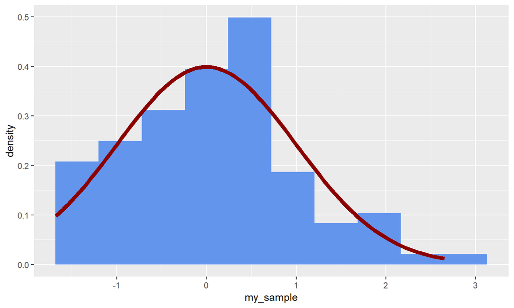

```r
ggplot(, aes(x = my_sample)) +
  geom_histogram(aes(y = ..density..), bins = 10, fill = "cornflowerblue")+
  stat_function(fun = dnorm, color = "darkred", size = 2)
```

## Estimating the mean with skew

```r
skewed_sample <- rexp(1000)
```

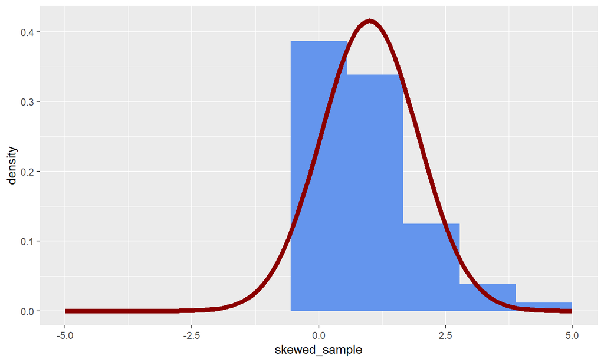

## Confidence

```r
my_test_2 <- tidy(t.test(skewed_sample))
my_test_2
```

```
## # A tibble: 1 x 8
##   estimate statistic   p.value parameter conf.low conf.high method
##      <dbl>     <dbl>     <dbl>     <dbl>    <dbl>     <dbl> <chr>
## 1    1.000      33.0 5.16e-162       999    0.940      1.06 One S~
## # ... with 1 more variable: alternative <chr>
```

## Ask yourself…

- Do you trust the t-confidence interval?
- Is the mean the best measure of center?
- How would you make a confidence interval for the median?

## Pull yourself up by your bootstraps!

## Idea:

- A large enough representative sample from a population is a good approximation for the distribution of the population.
- We could do better inference we had more samples.

Thus: Re-sample from our sample!

## Bootstrap it:

```r
sample(skewed_sample, replace = TRUE)
```

```
##    [1] 0.0863811400 1.3420081641 0.8182310713 0.4167195704 4.5553250709
##    [6] 0.6769396691 0.4834454209 1.9610541667 0.2831370973 0.0049065048
##   [11] 0.0669207284 2.0506558902 0.2270825003 0.0921442071 0.2097303666
##   [16] 0.0921442071 0.2421145346 0.3688550098 2.7087306956 1.0254232222
##   [21] 2.1969742525 0.1276459927 0.6688248538 0.5934691452 2.1089707105
##   [26] 1.0114679345 0.3939295644 1.0478524547 0.5634094011 0.3195806951
##   [31] 0.1983722164 0.6493756035 0.1373155569 2.7061723749 2.3720538783
##   [36] 1.4535980132 0.3278142894 0.8223306061 0.1144536062 0.1700681928
##   [41] 0.3363439264 2.2143001499 0.2499527377 0.7965147476 2.3822668771
##   [46] 0.0436905334 1.5927606615 1.0272600380 0.7102752570 0.0049065048
##   [51] 0.5359602011 0.1729599768 0.5549387573 1.1534350030 1.1669118039
##   [56] 0.2717671921 0.4825993758 2.2765821045 0.5462942766 0.7687207665
##   [61] 3.3903866185 1.8430152032 1.0864261230 3.2070360033 1.4691102616
##   [66] 1.2283940110 0.6559537407 0.9222059641 4.5417848115 1.6885582370
##   [71] 1.7164203244 1.0692923564 0.1758276499 1.4201943450 0.5556897209
```

[output cut: 185 more lines]

```r
# why is replace = TRUE important?
```

## Bootstrap it:

```r
my_boots <- replicate(1000, sample(skewed_sample, replace = TRUE), simplify = FALSE)
```

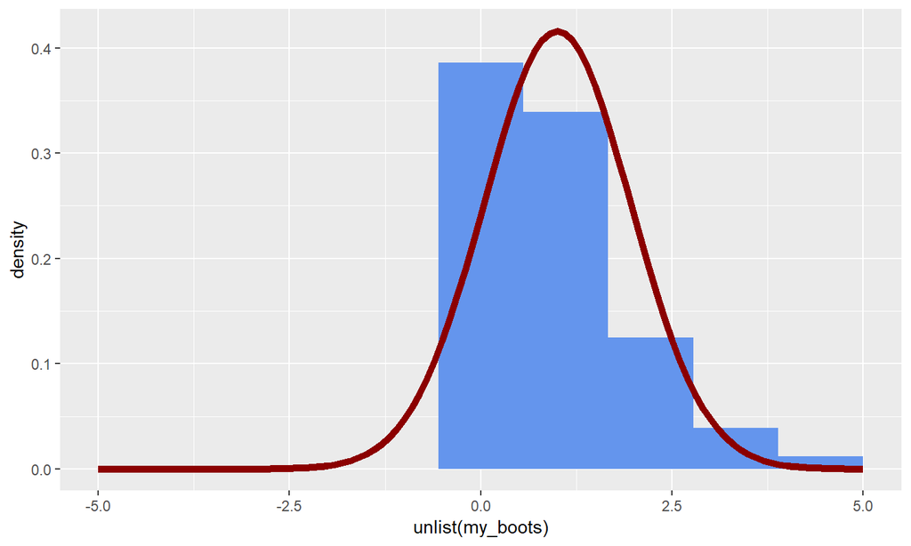

## Bootstrapped confidence

```r
my_stats <- data.frame(
  means = map_dbl(my_boots, mean),
  medians = map_dbl(my_boots, median)
)

head(my_stats)
```

```
##       means   medians
## 1 0.9636788 0.6444938
## 2 1.0063112 0.7131872
## 3 0.9556237 0.6691991
## 4 0.9909301 0.6808049
## 5 0.9879312 0.7110705
## 6 1.0403285 0.7432895
```

## Plot it

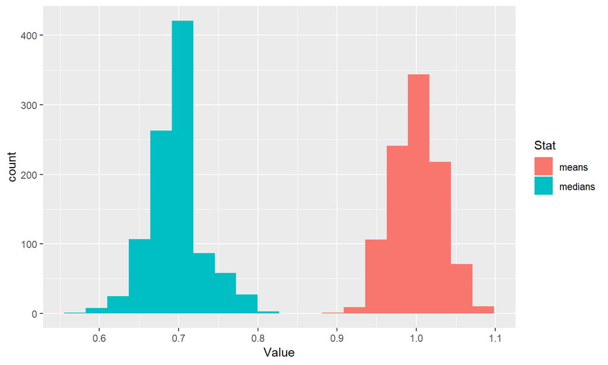

```r
my_stats %>%
  gather("Stat", "Value") %>%
ggplot(aes(x = Value, fill = Stat)) +
  geom_histogram(bins = 20)
```

## Confidence intervals

What range catches 95% of our bootstrap estimates?

```r
my_test_2 %>% select(conf.low, conf.high)
```

```
## # A tibble: 1 x 2
##   conf.low conf.high
##      <dbl>     <dbl>
## 1    0.940      1.06
```

```r
quantile(my_stats$means, c(0.025, 0.975))
```

```
##      2.5%     97.5%
## 0.9453076 1.0614328
```

```r
quantile(my_stats$medians, c(0.025, 0.975))
```

```
##      2.5%     97.5%
## 0.6314317 0.7796571
```

## Ask yourself…

- Do you trust the t-confidence interval?
- Is the mean the best measure of center?
- How would you make a confidence interval for the median?

## Very small samples

## Bootstrap vs. t-test

```r
small_sample <- rbinom(10, 1, 0.8)

tidy(t.test(small_sample)) %>% select(conf.low, conf.high)
```

```
## # A tibble: 1 x 2
##   conf.low conf.high
##      <dbl>     <dbl>
## 1    0.354      1.05
```

## Bootstrap vs. t-test

```r
my_boots <- replicate(1000, sample(small_sample, replace = TRUE), simplify = FALSE)

boot_means <- map_dbl(my_boots, mean)

quantile(boot_means, c(0.025, .975))
```

```
##  2.5% 97.5%
##   0.4   1.0
```

## Bootstrap vs. t

```r
boot_CIs <- data.frame()
t_CIs <- data.frame()
means <- c()

set.seed(35)
for(i in 1:10){

  my_sample <- rbinom(10, 1, .8)

  means <- c(means, mean(my_sample))

  boot_CIs <- rbind(boot_CIs, boot_it(my_sample))

  my_test <- tidy(t.test(my_sample)) %>% select(conf.low, conf.high)

  t_CIs <- rbind(t_CIs, my_test)

}
```

What is happening in this code?

## Bootstrap vs. t

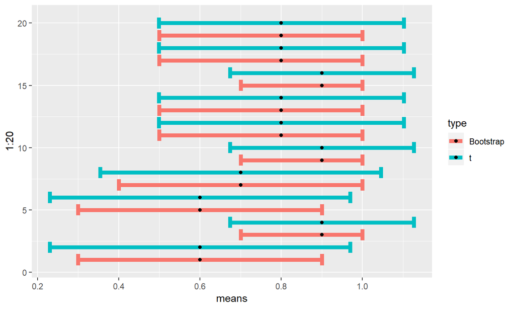

## Activity

## Automatic versus manual cars

Load the `mtcars` dataset into R by typing `data(mtcars)`.

This dataset contains information about 32 different cars.

Use bootstrapping to make a 95% confidence interval for the difference in horsepower (`hp`) between automatic (`am = 0`) and manual (`am = 1`) cars.

Write a sentence summarizing your findings in the PolyLearn assignment.